# Fundamentals of AI Project 1 - Cardio Good Fitness

## Observation

Given that the product is TM798, Men prefer TM798 over women (significantly)

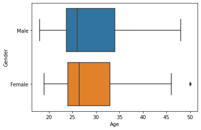

```python
#Display boxplot for age of customer and gender
sns.boxplot(data = cardio, x='Age',  y ="Gender")
plt.show()
```

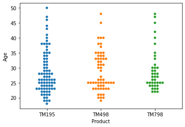

```python
#Display count of product by age of customer
sns.swarmplot(data=cardio, x='Product', y='Age');
```

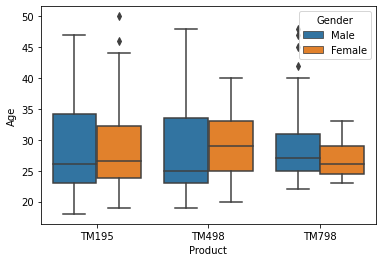

```python
# Display distribution of product by age of customer with emphasis on Gender
sns.boxplot(data = cardio, x='Product',  y ="Age", hue = 'Gender')
plt.show()
```

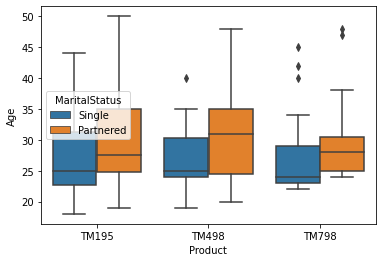

```python
# Display distribution of product by age  of customer with emphasis on Marital Status
sns.boxplot(data = cardio, x='Product',  y ="Age", hue = 'MaritalStatus')
plt.show()
```

### Education Level and Product

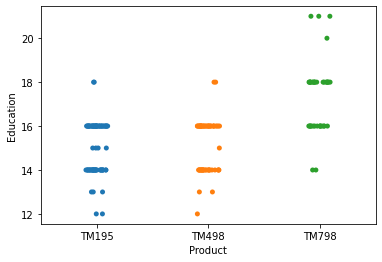

```python
#Display count of product by Education of customer
sns.stripplot(data=cardio, x='Product', y='Education');
```

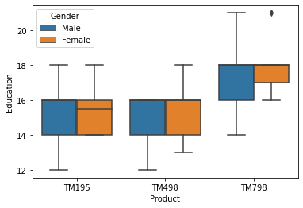

```python
# Display distribution of product by Education level of customer with emphasis on Gender
sns.boxplot(data = cardio, x='Product',  y ="Education", hue = 'Gender')
plt.show()
```

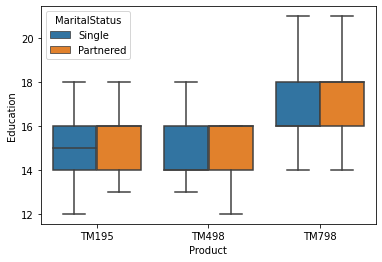

```python
# Display distribution of product by Education of customer with emphasis on Marital Status
sns.boxplot(data = cardio, x='Product',  y ="Education", hue = 'MaritalStatus')
plt.show()
```

### Usage and Product

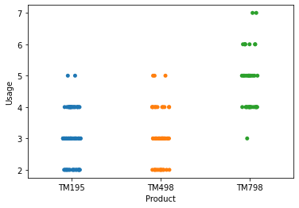

```python
#Display count of product by customer use of product
sns.stripplot(data=cardio, x='Product', y='Usage');
```

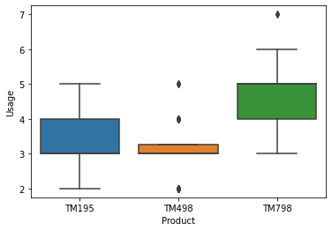

```python
# Display distribution of product by usage  of customer
sns.boxplot(data = cardio, x='Product',  y ="Usage")
plt.show()
```

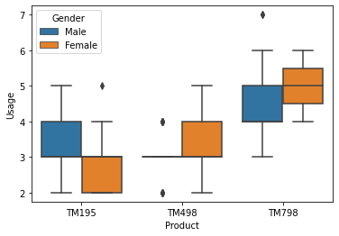

```python
# Display distribution of product by usage of customer with emphasis on Gender
sns.boxplot(data = cardio, x='Product',  y ="Usage", hue = 'Gender')
plt.show()
```

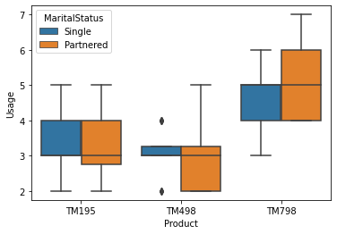

```python
# Display distribution of product by usage of customer with emphasis on Marital Status
sns.boxplot(data = cardio, x='Product',  y ="Usage", hue = 'MaritalStatus')
plt.show()
```

### Product and Fitness

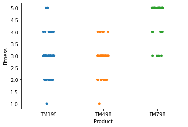

```python
#Display count of product by fitness level of custoemr
sns.stripplot(data=cardio, x='Product', y='Fitness');
```

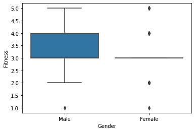

```python
#Fitness and Gender relationship
sns.boxplot(data = cardio, x='Gender',  y ="Fitness")
plt.show()
```

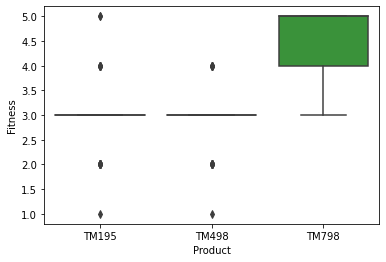

```python
# Display distribution of product by Fitness of customer
sns.boxplot(data = cardio, x='Product',  y ="Fitness")
plt.show()
```

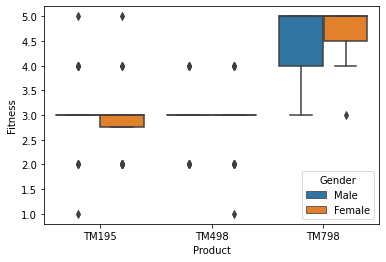

```python
# Display distribution of product by fitness of customer with emphasis on Gender
sns.boxplot(data = cardio, x='Product',  y ="Fitness", hue = 'Gender')
plt.show()
```

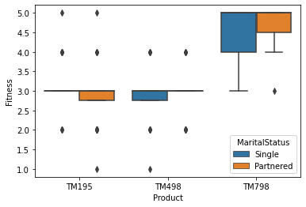

```python
# Display distribution of product by Fitness  of customer with emphasis on Marital Status
sns.boxplot(data = cardio, x='Product',  y ="Fitness", hue = 'MaritalStatus')
plt.show()
```

### Income and Product

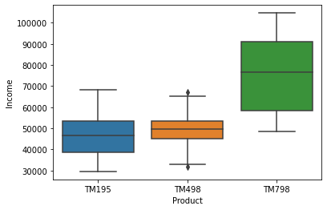

```python
# Display distribution of product by income  of customer
sns.boxplot(data = cardio, x='Product',  y ="Income")
plt.show()
```

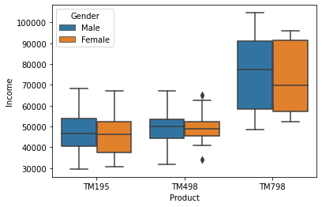

```python
# Display distribution of product by income of customer with emphasis on Gender
sns.boxplot(data = cardio, x='Product',  y ="Income", hue = 'Gender')
plt.show()
```

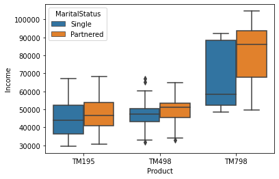

```python
# Display distribution of product by Income  of customer with emphasis on Marital Status
sns.boxplot(data = cardio, x='Product',  y ="Income", hue = 'MaritalStatus')
plt.show()
```

### Miles and Product

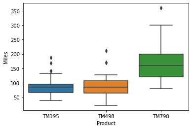

```python
# Display distribution of product by miles of customer
sns.boxplot(data = cardio, x='Product',  y ="Miles")
plt.show()
```

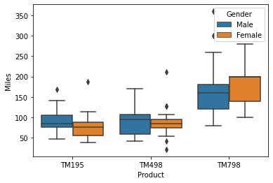

```python
# Display distribution of product by miles of customer with emphasis on Gender
sns.boxplot(data = cardio, x='Product',  y ="Miles", hue = 'Gender')
plt.show()
```

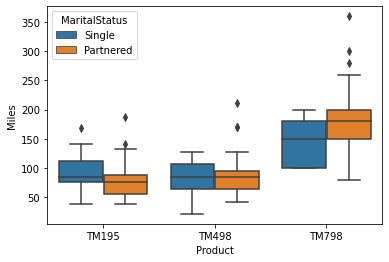

```python
# Display distribution of product by miles  of customer with emphasis on Marital Status
sns.boxplot(data = cardio, x='Product',  y ="Miles", hue = 'MaritalStatus')
plt.show()
```

# Recommendations

## Product TM798:

- male
- most probably between the ages of approximately 23 and 32 but also possibly less that 42 years of age. (Target customer between the ages of 23 and 42)
- has obtained a greater number of years of education
- intending to use the product more often that average (between 4-5 days per week)
  - Females may report higher usage intention that males
  - Customers with partners may report higher usage than singles -reporting higher levels of fitness that average (both male and female) -report higher incomes (at least 50000 per year and more likely between 59000 and 90000 peryear
  - Those who have a partner may have higher income that singles

**Target Customer:** The target customer for the TM798 is male between the ages of 23 and 32 with a higher than average income and an intent to use the treadmill 4 or ore days per week. This customer will have a greater than average number of years of education (above 14 years and most likely higher). The customer will report a higher than average income (above 50000 per year). The customer will also report an average or greater than average level of fitness and intent to walk/run higher number of miles than average.

## Product TM498:

Given the TM498 is the a likely purchase (2nd of the 3 stated products at 33.3%): The customer most likely to purchase TM498 is:

- male or female
- Probably between the ages of 24 and 34 but possibly as young as 18 and as old as 47.
  - If the customer is female, the likely age range falls between 20 and 42 with a more specific target of 26 to 34
- has obtained at least 12 years of education but more likely great than 14 years of education.
  - if female, the level of education might be slightly higher than male
- intending to use the product approximately 3 days per week
  - females may report an intent to use the product between 3-4 days per week
- reporting average fitness (approximately 3)
- reporting incomes between 32,000 and 63,000 but more likely between 42,000 and 52000

## Product TM195:

Given that TM195 is the most popular purchase (44.4%) The customer most likely to purchase TM 195:

- male or female
- between the ages of 18 and 47 but more likely between the ages of 23 and 34.
  - if female, the age range is slight less, at a target range of 24 to 33 extending outward as far as 19 to 44
- has obtained at least 12 years of education but more likely great than 14 years of education.
  - if female, the level of education might be slightly higher than male
- will intend to use the product between 2-5 days per week but more likely between 3-4 days per week
- reporting average fitness (approximately 3)
- reporting income levels slightly lower or higher than those that purchase the TM498 with primary range between 38000 and 51000